# SPC - Data Analysis - Lung Cancer Germany - Publication ‘Incidence of Smoking-related Second Primary Cancers after Lung Cancer in Germany’

Marian Eberl (TUM)

2021-10-19

#Set document paramenters

# Prepare Datasets

The used data set has is based on the ZfKD-Data-set Version 2018-08-24 incl. missing cases (4,736,067 patients with a total of 5,407,569 registered tumors) and has been pre-filtered according to the following criteria:

- patients with a first cancer diagnosis of lung cancer defined as:
  - `ICD10GM` starts with `C33` or `C34` AND
  - `t_tumid == 1` (Tumor ID created with `msSPChelpR::renumber_time_id_tt()` function and defined as chronologically sorting of all registered cases per patient ID by date of diagnosis, ignoring D diagnoses [in situ, benign and unknown behavior diagnoses] and C44 diagnoses [non-malignant melanoma])
- no further restrictions on age, registry, site, histology or data quality

It was created using the files:

- `73.01.cr_prefilter.fc.lung.zfkd.R` (last modified NA)
- `73.02.cr_dm.save.fc.lung.zfkd.R` (last modified NA)

The used analysis files are:

- ../1_input/73.zfkdspn.dataset.fc.lungcancer.RData (last modified 2021-04-08 13:09:58)
- ../1_input/73.zfkdspn.dataset.fc.lungcancer.wide.RData (last modified 2021-04-08 13:10:18)

The unfiltered data set contains 706943 patients with any lung cancer (C33-C34) and a total of 735635 registered tumors.

The used file for data analysis (this document) is:

- `x3.08.an_lung.publication1.Rmd` (last modified NA)

## Impute missing rates for DE2 and DE9 in rates

The analysis uses all cases diagnosed in the period 2002 to 2013 in 11 German regions (BY, BB, HB, HH, MV, NI, MÜN, SL, SN , SH, TH). However, reference rates are not available for all of these time periods. Therefore the following imputations are made:

- reference rates without DCO:
  - DE2 Bavaria, 2000 - 2004 fill up empty years with average available rates for the period 2005 - 2009 for the same region
  - DE9 Lower Saxony, 2000 - 2004 fill up empty years with average available rates for the period 2005 - 2009 for the same region
- reference rates including DCO:
  - DE2 Bavaria, 2000 - 2004 fill up empty years with average available rates for the period 2005 - 2009 for the same region
  - DE9 Lower Saxony, 2000 - 2004 fill up empty years with average available rates for the period 2005 - 2009 for the same region

## Prepare main dataset

### Remove columns not needed

### p_spc - Determine if second cancer did occur

### p_status - Determine patient status at end of FU end of 2014

| TOD.1 | p_status | N |
| --- | --- | --- |
| yes (patient deceased) | 3 | 572047 |
| yes (patient deceased) | 4 | 21321 |
| no (patient alive) | 1 | 90782 |
| yes (patient deceased) | 2 | 1015 |
| yes (patient deceased) | 1 | 16237 |
| no (patient alive) | 2 | 4636 |
| yes (patient deceased) | 99 | 905 |

| p_status | N |
| --- | --- |
| 3 | 572047 |
| 4 | 21321 |
| 1 | 107019 |
| 2 | 5651 |
| 99 | 905 |

### t_icdgroup_s.2 - group SPCs into categories where smoking-related cancers are separated

### t_icdgroup_pub.2 - group SPCs into categories used in publication

### t_icdgroup_pubdet.2 - group SPCs into categories used in publication; more detail on C00-C14

### p_futimeyrs - Calculate FU time

### p_futimegroup - FU time categorical

### p_agefcgroup - Age at first cancer diagnosis categorical

### t_smokeiarc.2 - Smoking-related cancer according to IARC definition

### p_region_recode - Region variable

```
mutate: new variable 'p_region_recode' (factor) with 16 unique values and 0% NA
mutate: converted 'p_region_recode' from factor to character (0 new NA)
```

### t_singleyeardiag.1 - Year of diagnosis

### p_yearfcgroup - Year of diagnosis FC diagnosis (4-year groups)

### p_statusevent - Patient status (events: SPC developed, dead after LC, no event at end of FU time)

### reset all SPC relevant data if spc developed after end of FU

| p_spc | p_status | n |
| --- | --- | --- |
| No SPC | 1 | 107019 |
| No SPC | 3 | 572047 |
| No SPC | 99 | 890 |
| SPC developed | 2 | 5651 |
| SPC developed | 4 | 21321 |
| SPC developed | 99 | 15 |

| p_spc | p_status | DDIMP.2 | n |
| --- | --- | --- | --- |

## Create different filtered dataset versions

### Dataset 0: all registries, all times

### ASIR by region (to investigate registry completeness)

```
Using person-years at risk [PYAR] from reference population as pyears for calculating incidence rates.
Be careful, in this calculation it is assumed that all included regions have collected data for the full time period: 1970 to 2014
                       If you have included registries with differing times, please check this assumption by looking at groups with 0 incidence and specify option 'inclusion_restrictions' if needed.
The following regions, age groups, years, sexes and ICD codes are considered:  DE1 Baden-Wuerttemberg, DE2 Bavaria, DE3 Berlin, DE4 Brandenburg, DE5 Bremen, DE6 Hamburg, DE7 Hesse, DE8 Mecklenburg-Western Pomerania, DE9 Lower Saxony, DEA North Rhine-Westphalia, DEA3 Muenster, DEB Rhineland-Palatinat…
For the following age-groups there were no cases to be found in the dataset. Incidence and PYARs will be set to 0: 00 - 04, 05 - 09, 10 - 14
```

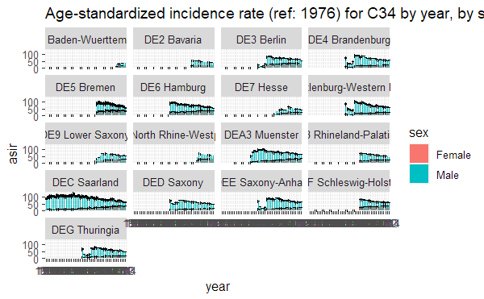

```
Using person-years at risk [PYAR] from reference population as pyears for calculating incidence rates.
Be careful, in this calculation it is assumed that all included regions have collected data for the full time period: 1970 to 2014
                       If you have included registries with differing times, please check this assumption by looking at groups with 0 incidence and specify option 'inclusion_restrictions' if needed.
The following regions, age groups, years, sexes and ICD codes are considered:  DE1 Baden-Wuerttemberg, DE2 Bavaria, DE3 Berlin, DE4 Brandenburg, DE5 Bremen, DE6 Hamburg, DE7 Hesse, DE8 Mecklenburg-Western Pomerania, DE9 Lower Saxony, DEA North Rhine-Westphalia, DEA3 Muenster, DEB Rhineland-Palatinat…
For the following age-groups there were no cases to be found in the dataset. Incidence and PYARs will be set to 0: 00 - 04, 05 - 09, 10 - 14
```

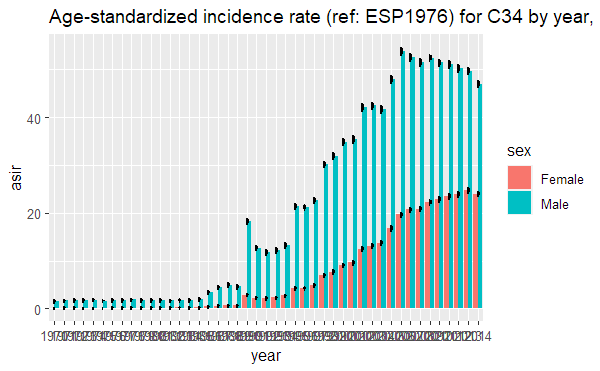

### Dataset 1: GEKID recommended registries, 2002-2013 (FC incidence); age 30-99 at LC diagnosis, 6 months latency LC and SPC , only 1st and 2nd cancer,end of follow-up 2014 (UK replication - Barclay et al 2019)

[output not shown]

### Dataset 1raw : For ASIR calculations GEKID recommended registries, 2002-2013 (FC incidence) end of follow-up 2014

This is the Data-set 1 equivalent, but skips filter steps S3, S4, S5 and S6. It is intended for ASIR calculations,

```
filter: removed 218,387 rows (31%), 488,556 rows remaining
filter: removed 223,796 rows (46%), 264,760 rows remaining
```

### Dataset 2: No latency, incl. DCO.1, GEKID recommended registries, 2002-2013 (FC incidence); age 30-99 at LC diagnosis, no minimum latency between LC and SPC, end of follow-up 2014 (UK replication - Barclay et al 2019)

This is the Data-set 1 equivalent, but skips filter steps S4 and S5, so no minimal follow-up after lung cancer is required.

[output not shown]

### Dataset 3: No latency, excl. DCO.1, GEKID recommended registries, 2002-2013 (FC incidence); age 30-99 at LC diagnosis, no minimum latency between LC and SPC, end of follow-up 2014 (UK replication - Barclay et al 2019)

This is the Data-set 1 equivalent, but skips filter step S5, so no minimal follow-up after lung cancer is required, but DCO at LC are excluded.

[output not shown]

# Statistical Analyses

## Descriptives

### DCO rates

- percentage of DCO in primary LC 14.75%

DCO rates for LC in all regions but Saarland: 9.85%.

DCO rates for SPC in Saarland: 6.85%.

DCO rates for SPC in all regions but Saarland: 24.2%.

### Table 1: Descriptives

#### Prepare Table 1

- Descriptive statistics (ASIR, sex, age, mean follow-up, Incidence of SPC) o Table 1: Descriptive statistics (incl. summary of missing data) o Most frequent sites for SPC after lung cancer (does SPC occur in smoking-related cancer sites as defined by IARC?)

[output not shown]

#### Plots for Table 1

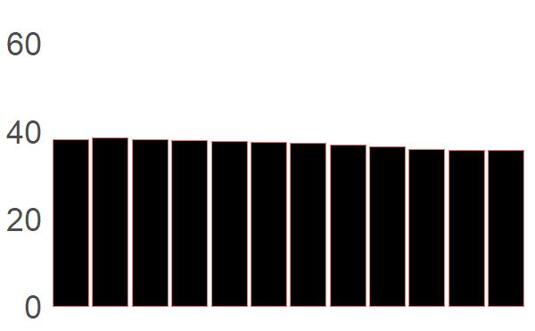

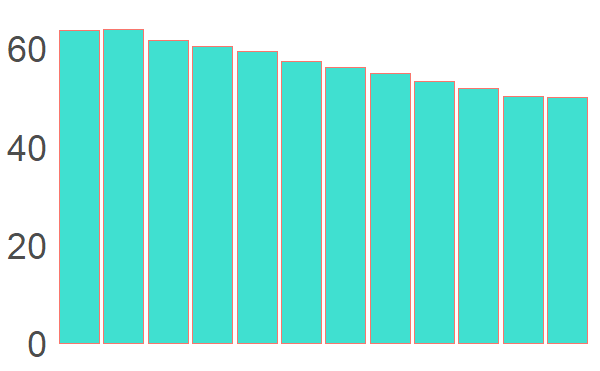

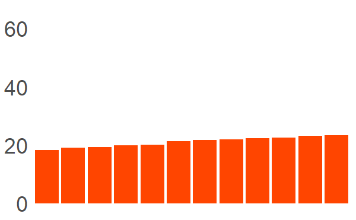

#### Table 1: Put parts together

Table 1 Characteristics of analyzed study population with primary lung cancer

Number of patients with primary index lung cancer, age-standardized incidence rates of primary lung cancer (ASIR), follow-up time, characteristics of patients included in main analysis with at least 6 months of survival and absolute incidence of second primary cancer (SPC) by sex

[output not shown]

ASIR age-standardized incidence rate based on the European Standard Population 1976 for the population aged 30+; DCO death-certificate only; IR incidence rate; LC primary lung cancer; NSCLC non-small-cell lung carcinoma; PYAR person-years at risk; SPC second primary cancer  
<sup>*1*</sup> after exclusion by age and morphology unusual, benign, sarcoma <sup>*2*</sup> DCO cases and cases with unknown or less than 6 months follow-up time are excluded from further analyses.

### Case-number when including all cases independent of FU time and all LC DCO (flow-chart)

- Complete database (ZfKD all regions, all tumors)
  - n = 4,736,067 patients
- S0: all patients with primary lung cancer (C33-C34)
  - n = 706943
- S1: LC diagnosis between 2000 and 2013
  - n = 488556
- S2: in regions that have registries with acceptable data quality (GEKID recommended)
  - n = 264760
- S3: LC diagnosis at age 30 to 99
  - n = 264475
- S6: morphology of LC not unusual, benign, sarcoma
  - n = 263921

## SIR calculations

### Calculate SIRs by sex and cancer site

[output not shown]

| yvar_name | yvar_label | fu_time | age | sex | region | year | t_site | i_observed | i_pyar | n_base | incidence_cases | incidence_crude_rate | population_pyar | i_expected | sir | sir_lci | sir_uci | fu_time_sort | yvar_sort |
| --- | --- | --- | --- | --- | --- | --- | --- | --- | --- | --- | --- | --- | --- | --- | --- | --- | --- | --- | --- |
| total_var | Overall | 6-12 months | 45 - 49 | Female | DE6 Hamburg | 2013 | C38 | 1 | 2.58281999 | 7 | 0.2 | 0.2840477 | 70410.7 | 7.336442e-06 | 136305.8602 | 3.450966e+03 | 759447.645 | 1 | 1 |
| total_var | Overall | 6-12 months | 45 - 49 | Female | DE6 Hamburg | 2013 | C65 | 1 | 2.58281999 | 7 | 0.2 | 0.2840477 | 70410.7 | 7.336442e-06 | 136305.8602 | 3.450966e+03 | 759447.645 | 1 | 1 |
| total_var | Overall | 6-12 months | 45 - 49 | Female | DEA3 Muenster | 2010 | C68 | 1 | 4.08110883 | 9 | 0.2 | 0.1792916 | 111550.1 | 7.317087e-06 | 136666.4118 | 3.460094e+03 | 761456.510 | 1 | 1 |
| total_var | Overall | 6-12 months | 45 - 49 | Male | DE4 Brandenburg | 2002 | C45 | 1 | 10.66837782 | 27 | 0.6 | 0.5528283 | 108532.8 | 5.897781e-05 | 16955.5300 | 4.292769e+02 | 94470.167 | 1 | 1 |
| total_var | Overall | 6-12 months | 50 - 54 | Female | DE4 Brandenburg | 2005 | C84 | 1 | 11.92505133 | 27 | 0.8 | 0.7851404 | 101892.6 | 9.362840e-05 | 10680.5201 | 2.704074e+02 | 59508.049 | 1 | 1 |
| total_var | Overall | 6-12 months | 50 - 54 | Female | DE6 Hamburg | 2006 | C38 | 1 | 8.82751540 | 22 | 0.0 | 0.0000000 | 53121.8 | 0.000000e+00 | Inf | Inf | Inf | 1 | 1 |
| total_var | Overall | 6-12 months | 50 - 54 | Male | DE9 Lower Saxony | 2009 | C68 | 1 | 59.57563313 | 138 | 0.8 | 0.2938171 | 272278.2 | 1.750434e-04 | 5712.8684 | 1.446373e+02 | 31830.065 | 1 | 1 |
| total_var | Overall | 6-12 months | 55 - 59 | Female | DE9 Lower Saxony | 2006 | C68 | 1 | 37.66255989 | 86 | 0.4 | 0.1633464 | 244878.4 | 6.152043e-05 | 16254.7634 | 4.115350e+02 | 90565.745 | 1 | 1 |
| total_var | Overall | 6-12 months | 55 - 59 | Female | DED Saxony | 2008 | C76 | 1 | 12.82614648 | 30 | 0.6 | 0.4179204 | 143568.0 | 5.360309e-05 | 18655.6422 | 4.723200e+02 | 103942.586 | 1 | 1 |
| total_var | Overall | 6-12 months | 55 - 59 | Male | DE8 Mecklenburg-Western Pomerania | 2008 | C03 | 1 | 21.92642026 | 55 | 0.4 | 0.7111870 | 56244.0 | 1.559378e-04 | 6412.8115 | 1.623583e+02 | 35729.899 | 1 | 1 |

[output cut: 990 more lines]

[output not shown]

[output not shown]

| yvar_name | yvar_label | fu_time | age | sex | region | year | t_site | i_observed | i_pyar | n_base | incidence_cases | incidence_crude_rate | population_pyar | i_expected | sir | sir_lci | sir_uci | fu_time_sort | yvar_sort |
| --- | --- | --- | --- | --- | --- | --- | --- | --- | --- | --- | --- | --- | --- | --- | --- | --- | --- | --- | --- |
| total_var | Overall | 6-12 months | 45 - 49 | Female | DE6 Hamburg | 2013 | C38 | 1 | 2.58281999 | 7 | 0.2 | 0.2840477 | 70410.7 | 7.336442e-06 | 136305.8602 | 3.450966e+03 | 7.594476e+05 | 2 | 1 |
| total_var | Overall | 6-12 months | 45 - 49 | Female | DE6 Hamburg | 2013 | C65 | 1 | 2.58281999 | 7 | 0.2 | 0.2840477 | 70410.7 | 7.336442e-06 | 136305.8602 | 3.450966e+03 | 7.594476e+05 | 2 | 1 |
| total_var | Overall | 6-12 months | 45 - 49 | Female | DEA3 Muenster | 2010 | C68 | 1 | 4.08110883 | 9 | 0.2 | 0.1792916 | 111550.1 | 7.317087e-06 | 136666.4118 | 3.460094e+03 | 7.614565e+05 | 2 | 1 |
| total_var | Overall | 6-12 months | 45 - 49 | Male | DE4 Brandenburg | 2002 | C45 | 1 | 10.66837782 | 27 | 0.6 | 0.5528283 | 108532.8 | 5.897781e-05 | 16955.5300 | 4.292769e+02 | 9.447017e+04 | 2 | 1 |
| total_var | Overall | 6-12 months | 50 - 54 | Female | DE4 Brandenburg | 2005 | C84 | 1 | 11.92505133 | 27 | 0.8 | 0.7851404 | 101892.6 | 9.362840e-05 | 10680.5201 | 2.704074e+02 | 5.950805e+04 | 2 | 1 |
| total_var | Overall | 6-12 months | 50 - 54 | Female | DE6 Hamburg | 2006 | C38 | 1 | 8.82751540 | 22 | 0.0 | 0.0000000 | 53121.8 | 0.000000e+00 | Inf | Inf | Inf | 2 | 1 |
| total_var | Overall | 6-12 months | 50 - 54 | Male | DE9 Lower Saxony | 2009 | C68 | 1 | 59.57563313 | 138 | 0.8 | 0.2938171 | 272278.2 | 1.750434e-04 | 5712.8684 | 1.446373e+02 | 3.183007e+04 | 2 | 1 |
| total_var | Overall | 6-12 months | 55 - 59 | Female | DE9 Lower Saxony | 2006 | C68 | 1 | 37.66255989 | 86 | 0.4 | 0.1633464 | 244878.4 | 6.152043e-05 | 16254.7634 | 4.115350e+02 | 9.056575e+04 | 2 | 1 |
| total_var | Overall | 6-12 months | 55 - 59 | Female | DED Saxony | 2008 | C76 | 1 | 12.82614648 | 30 | 0.6 | 0.4179204 | 143568.0 | 5.360309e-05 | 18655.6422 | 4.723200e+02 | 1.039426e+05 | 2 | 1 |
| total_var | Overall | 6-12 months | 55 - 59 | Male | DE8 Mecklenburg-Western Pomerania | 2008 | C03 | 1 | 21.92642026 | 55 | 0.4 | 0.7111870 | 56244.0 | 1.559378e-04 | 6412.8115 | 1.623583e+02 | 3.572990e+04 | 2 | 1 |

[output cut: 990 more lines]

[output not shown]

[output not shown]

### Determine sites for which to present detailed information in main tables and figures

All sites that have at least 100 observed or 100 expected cases are presented in the main analyses (Table 2, Figure 1). SIRs for all other sites are presented in the supplement.

```
 [1] TRUE TRUE TRUE TRUE TRUE TRUE TRUE TRUE TRUE TRUE TRUE TRUE
[13] TRUE TRUE TRUE
```

### Highest SIR for all sexes, males and females

| t_site | t_smokeiarc | sex | sir | observed | expected | sir_lci | sir_uci |
| --- | --- | --- | --- | --- | --- | --- | --- |
| Larynx (C32) | smoking-related IARC | Total | 3.88 | 170 | 43.80804 | 3.32 | 4.51 |
| Pharynx (C10-C14) | smoking-related IARC | Total | 3.18 | 123 | 38.66222 | 2.64 | 3.80 |
| Oral cavity (C01-C06) | smoking-related IARC | Total | 2.90 | 149 | 51.31832 | 2.46 | 3.41 |
| Esophagus (C15) | smoking-related IARC | Total | 2.70 | 181 | 66.97593 | 2.32 | 3.13 |
| Urinary tract (C65-C68) | smoking-related IARC | Total | 2.32 | 437 | 188.14506 | 2.11 | 2.55 |

| t_site | t_smokeiarc | sex | sir | observed | expected | sir_lci | sir_uci |
| --- | --- | --- | --- | --- | --- | --- | --- |
| Larynx (C32) | smoking-related IARC | Male | 3.70 | 154 | 41.58392 | 3.14 | 4.34 |
| Pharynx (C10-C14) | smoking-related IARC | Male | 3.17 | 112 | 35.34826 | 2.61 | 3.81 |
| Oral cavity (C01-C06) | smoking-related IARC | Male | 2.86 | 124 | 43.34431 | 2.38 | 3.41 |
| Esophagus (C15) | smoking-related IARC | Male | 2.49 | 151 | 60.54078 | 2.11 | 2.93 |
| Urinary tract (C65-C68) | smoking-related IARC | Male | 2.27 | 377 | 165.74307 | 2.05 | 2.52 |

| t_site | t_smokeiarc | sex | sir | observed | expected | sir_lci | sir_uci |
| --- | --- | --- | --- | --- | --- | --- | --- |
| Esophagus (C15) | smoking-related IARC | Female | 4.66 | 30 | 6.435153 | 3.15 | 6.66 |
| Urinary tract (C65-C68) | smoking-related IARC | Female | 2.68 | 60 | 22.401993 | 2.04 | 3.45 |
| Kidney (C64) | smoking-related IARC | Female | 2.10 | 57 | 27.178320 | 1.59 | 2.72 |
| Lung (C33-C34) | smoking-related IARC | Female | 2.07 | 156 | 75.332173 | 1.76 | 2.42 |
| Cervix (C53) | smoking-related IARC | Female | 1.96 | 31 | 15.853163 | 1.33 | 2.78 |

### Figure 1

#### Prepare Figure 1: Calculate Rates

#### Prepare Figure 1: Plot single sites

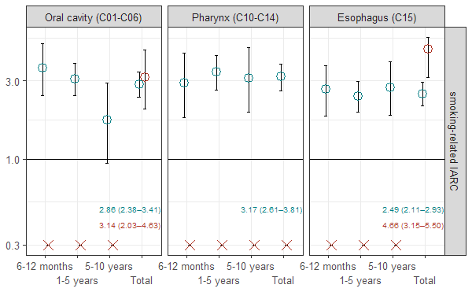

#### Prepare Figure 1: Plot grouped sites smoking related

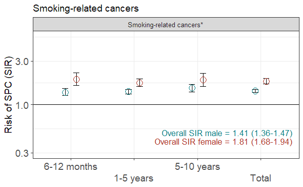

#### Prepare Figure 1: Plot grouped sites other

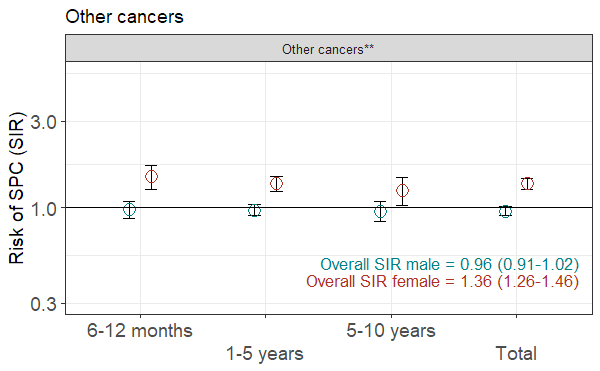

#### Figure 1: Put parts together

[output not shown]

[figure not shown]

### Table 2

#### Prepare Table 2

#### Create single plots

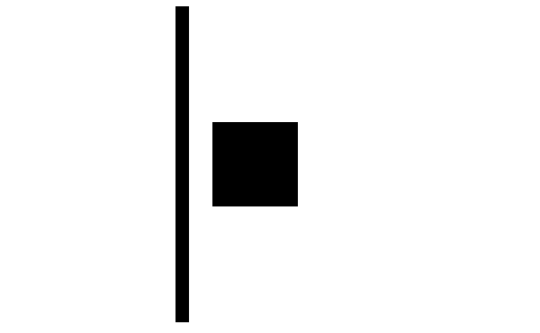

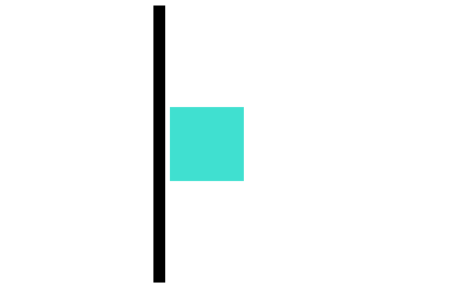

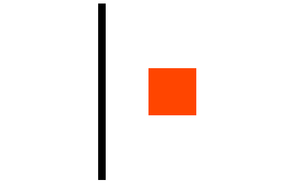

#### Table 2: Put parts together

Table 2 Relative incidence of SPC stratified by follow-up time

Number of observed and expected SPC in main analysis (n=135,589) and standardized incidence ratios overall, by sex, by index lung cancer diagnosis and for grouped smoking-related and grouped other cancers, stratified by follow-up time.

| All sites combined | Total O | Total E | Total SIR | Total 95% CI | Total PYAR | Total N | 6-12 months SIR | 6-12 months 95% CI | 1-5 years SIR | 1-5 years 95% CI | 5-10 years SIR | 5-10 years 95% CI | 10+ years SIR | 10+ years 95% CI |
| --- | --- | --- | --- | --- | --- | --- | --- | --- | --- | --- | --- | --- | --- | --- |
| Overall | 5,298 | 4,116 | 1.29 | 1.25–1.32 | 280,155 | 135589 | 1.29 | 1.22–1.37 | 1.28 | 1.23–1.32 | 1.32 | 1.24–1.41 | 1.20 | 0.97–1.47 |
| Female | 1,492 | 962 | 1.55 | 1.47–1.63 | 95,827 | 43144 | 1.66 | 1.48–1.85 | 1.52 | 1.42–1.62 | 1.51 | 1.33–1.70 | 1.77 | 1.22–2.49 |
| Male | 3,806 | 3,153 | 1.21 | 1.17–1.25 | 184,327 | 92445 | 1.19 | 1.11–1.28 | 1.20 | 1.15–1.25 | 1.26 | 1.17–1.36 | 1.02 | 0.78–1.32 |
| Age at LC diagnosis |  |  |  |  |  |  |  |  |  |  |  |  |  |  |
| 30 - 54 | 528 | 191 | 2.77 | 2.54–3.01 | 49,577 | 20820 | 2.92 | 2.37–3.54 | 2.67 | 2.37–3.00 | 2.81 | 2.33–3.36 | 3.48 | 2.06–5.49 |
| 55 - 59 | 534 | 292 | 1.83 | 1.68–1.99 | 36,067 | 16333 | 2.18 | 1.81–2.61 | 1.71 | 1.52–1.91 | 1.83 | 1.50–2.21 | 2.02 | 1.11–3.40 |
| 60 - 64 | 966 | 605 | 1.60 | 1.50–1.70 | 48,821 | 21999 | 1.37 | 1.16–1.60 | 1.63 | 1.50–1.77 | 1.71 | 1.49–1.95 | 1.59 | 1.04–2.33 |
| 65 - 69 | 1,262 | 955 | 1.32 | 1.25–1.40 | 55,471 | 25684 | 1.31 | 1.15–1.48 | 1.34 | 1.24–1.43 | 1.30 | 1.15–1.48 | 1.18 | 0.74–1.78 |
| 70 - 74 | 1,008 | 983 | 1.03 | 0.96–1.09 | 46,389 | 23995 | 1.05 | 0.92–1.20 | 1.01 | 0.93–1.10 | 1.08 | 0.93–1.25 | 0.67 | 0.34–1.21 |
| 75 - 79 | 665 | 705 | 0.94 | 0.87–1.02 | 29,015 | 16374 | 1.07 | 0.92–1.24 | 0.95 | 0.86–1.05 | 0.78 | 0.63–0.97 | 0.30 | 0.06–0.87 |
| 80 - 84 | 260 | 306 | 0.85 | 0.75–0.96 | 11,799 | 7860 | 0.97 | 0.77–1.21 | 0.90 | 0.77–1.05 | 0.44 | 0.26–0.71 | 0.00 | 0.00–0.91 |
| 85+ | 75 | 80 | 0.93 | 0.74–1.17 | 3,017 | 2524 | 1.20 | 0.81–1.72 | 0.88 | 0.63–1.20 | 0.49 | 0.13–1.25 | 0.00 | 0.00–6.67 |
| Year of LC diagnosis |  |  |  |  |  |  |  |  |  |  |  |  |  |  |
| 2002 - 2005 | 2,245 | 1,679 | 1.34 | 1.28–1.39 | 115,984 | 42167 | 1.39 | 1.25–1.54 | 1.33 | 1.26–1.41 | 1.33 | 1.23–1.44 | 1.20 | 0.97–1.47 |
| 2006 - 2009 | 1,942 | 1,559 | 1.25 | 1.19–1.30 | 103,795 | 46213 | 1.30 | 1.17–1.43 | 1.21 | 1.15–1.28 | 1.30 | 1.17–1.45 | NA | NA |
| 2010 - 2013 | 1,111 | 877 | 1.27 | 1.19–1.34 | 60,376 | 47209 | 1.20 | 1.08–1.33 | 1.30 | 1.21–1.40 | NA | NA | NA | NA |
| Regional cancer registry |  |  |  |  |  |  |  |  |  |  |  |  |  |  |
| DE2 Bavaria | 1,353 | 975 | 1.39 | 1.31–1.46 | 71,827 | 33357 | 1.43 | 1.27–1.61 | 1.39 | 1.30–1.49 | 1.28 | 1.11–1.46 | 1.92 | 1.30–2.75 |
| DE4 Brandenburg | 304 | 288 | 1.06 | 0.94–1.18 | 19,329 | 9740 | 0.69 | 0.50–0.93 | 1.04 | 0.90–1.21 | 1.55 | 1.21–1.94 | 1.61 | 0.65–3.32 |
| DE5 Bremen | 135 | 112 | 1.20 | 1.01–1.42 | 7,427 | 3214 | 1.08 | 0.68–1.61 | 1.23 | 0.98–1.53 | 1.21 | 0.81–1.74 | 1.46 | 0.40–3.73 |
| DE6 Hamburg | 304 | 208 | 1.46 | 1.30–1.64 | 14,070 | 6926 | 1.75 | 1.38–2.18 | 1.38 | 1.18–1.61 | 1.37 | 1.01–1.81 | 1.71 | 0.63–3.71 |
| DE8 Mecklenburg-Western Pomerania | 223 | 191 | 1.17 | 1.02–1.33 | 12,362 | 6536 | 0.85 | 0.60–1.18 | 1.14 | 0.96–1.36 | 1.74 | 1.31–2.27 | 0.65 | 0.08–2.35 |
| DE9 Lower Saxony | 1,227 | 875 | 1.40 | 1.33–1.48 | 57,884 | 28735 | 1.59 | 1.42–1.78 | 1.36 | 1.26–1.47 | 1.41 | 1.23–1.61 | 0.60 | 0.32–1.03 |
| DEA3 Muenster | 400 | 305 | 1.31 | 1.19–1.45 | 20,048 | 10001 | 1.17 | 0.92–1.46 | 1.35 | 1.18–1.53 | 1.42 | 1.12–1.78 | 0.60 | 0.12–1.75 |
| DEC Saarland | 120 | 156 | 0.77 | 0.64–0.92 | 10,460 | 4741 | 0.67 | 0.41–1.03 | 0.85 | 0.67–1.07 | 0.71 | 0.45–1.05 | 0.00 | 0.00–1.14 |
| DED Saxony | 466 | 429 | 1.09 | 0.99–1.19 | 27,578 | 13561 | 1.09 | 0.89–1.33 | 1.05 | 0.93–1.18 | 1.16 | 0.93–1.44 | 1.63 | 0.84–2.84 |
| DEF Schleswig-Holstein | 531 | 352 | 1.51 | 1.38–1.64 | 23,363 | 11405 | 1.61 | 1.34–1.93 | 1.50 | 1.34–1.68 | 1.39 | 1.12–1.71 | 1.61 | 0.83–2.81 |
| DEG Thuringia | 235 | 225 | 1.04 | 0.91–1.19 | 15,805 | 7373 | 0.87 | 0.62–1.19 | 1.05 | 0.88–1.24 | 1.21 | 0.90–1.58 | 1.18 | 0.38–2.75 |
| Histology of LC |  |  |  |  |  |  |  |  |  |  |  |  |  |  |
| Adenocarcinoma | 1,826 | 1,397 | 1.31 | 1.25–1.37 | 101,649 | 46899 | 1.40 | 1.26–1.54 | 1.28 | 1.20–1.35 | 1.28 | 1.14–1.43 | 1.64 | 1.18–2.23 |
| Carcinoid | 135 | 99 | 1.37 | 1.15–1.62 | 9,775 | 2046 | 1.83 | 1.12–2.82 | 1.32 | 1.05–1.65 | 1.43 | 1.01–1.97 | 0.00 | 0.00–1.30 |
| Other NSCLC | 553 | 462 | 1.20 | 1.10–1.30 | 32,560 | 15377 | 1.08 | 0.88–1.31 | 1.27 | 1.14–1.41 | 1.11 | 0.90–1.37 | 1.04 | 0.48–1.97 |
| Small-cell carcinoma | 532 | 428 | 1.24 | 1.14–1.35 | 32,404 | 24361 | 1.20 | 1.02–1.40 | 1.27 | 1.13–1.42 | 1.29 | 1.02–1.60 | 0.98 | 0.39–2.02 |
| Squamous cell carcinoma | 1,988 | 1,493 | 1.33 | 1.27–1.39 | 89,795 | 38812 | 1.30 | 1.17–1.43 | 1.31 | 1.23–1.39 | 1.47 | 1.33–1.61 | 1.11 | 0.77–1.56 |
| Unspecified lung | 264 | 238 | 1.11 | 0.98–1.25 | 13,972 | 8094 | 1.27 | 1.00–1.59 | 1.09 | 0.92–1.27 | 0.99 | 0.69–1.37 | 0.81 | 0.22–2.08 |
| Site of SPC |  |  |  |  |  |  |  |  |  |  |  |  |  |  |
| Smoking-related cancers - Total | 3,158 | 2,123 | 1.49 | 1.44–1.54 | 280,155 | 135589 | 1.47 | 1.36–1.59 | 1.46 | 1.39–1.53 | 1.59 | 1.47–1.72 | 1.57 | 1.21–2.00 |
| Other cancers - Total | 2,140 | 1,993 | 1.07 | 1.03–1.12 | 280,155 | 135589 | 1.11 | 1.01–1.21 | 1.08 | 1.02–1.14 | 1.04 | 0.94–1.15 | 0.80 | 0.54–1.15 |
| Smoking-related cancers - Male | 2,414 | 1,711 | 1.41 | 1.36–1.47 | 184,327 | 92445 | 1.37 | 1.26–1.50 | 1.39 | 1.32–1.47 | 1.52 | 1.38–1.66 | 1.39 | 1.02–1.86 |
| Other cancers - Male | 1,392 | 1,443 | 0.96 | 0.91–1.02 | 184,327 | 92445 | 0.98 | 0.87–1.09 | 0.97 | 0.91–1.04 | 0.96 | 0.84–1.09 | 0.57 | 0.32–0.93 |
| Smoking-related cancers - Female | 744 | 412 | 1.81 | 1.68–1.94 | 95,827 | 43144 | 1.90 | 1.62–2.22 | 1.74 | 1.58–1.91 | 1.87 | 1.58–2.21 | 2.31 | 1.37–3.65 |
| Other cancers - Female | 748 | 550 | 1.36 | 1.26–1.46 | 95,827 | 43144 | 1.48 | 1.26–1.72 | 1.36 | 1.23–1.49 | 1.24 | 1.03–1.47 | 1.39 | 0.78–2.29 |

Notes: E number of cases expected according to age-, sex-, region- and period-specific reference rates for the general population; LC primary lung cancer; NSCLC non-small-cell lung carcinoma; O number of cases observed in the data; PYAR person-years at risk; SIR standardized incidence ratio; SPC second primary cancer

#### Table 2 inkl. plots: Put parts together

In our analysis cohort 59.6% of SPC after lung cancer develop in smoking-related sites when applying the IARC definition of smoking-relatedness, whereas only 51.6% smoking-related cancers would have been expected if the distribution was equal to the general population.

### Figure 2: SIRs smoking related vs. other cancers depending on definition

#### Prepare Fig2: Calculate SIRs needed

#### Prepare Fig2: Calculate Smo-R

#### Prepare Fig2: Modify results

#### Prepare Fig2: Single plots

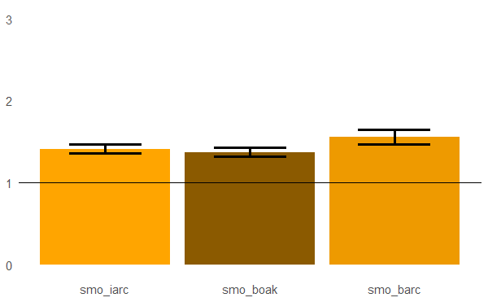

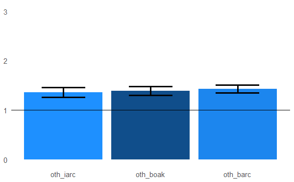

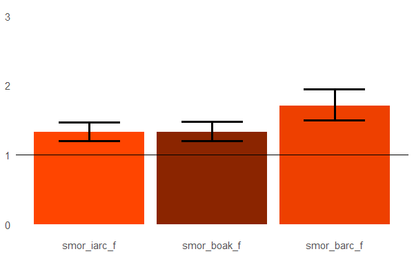

#### Prepare Fig2: Single plots barcharts

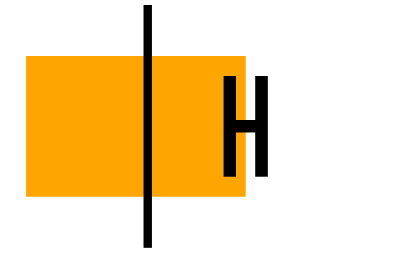

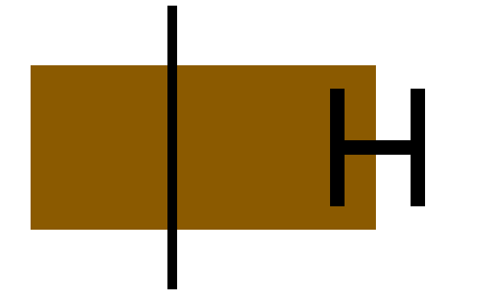

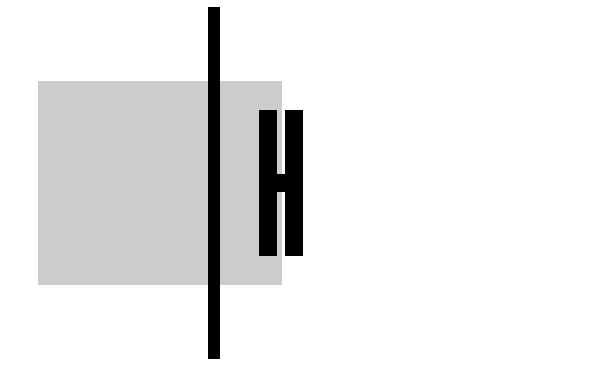

#### Prepare Fig2: Tabulate

#### Save Fig2 as file

Total

Male

Female

Estimate

95% CI

Estimate

95% CI

Estimate

95% CI

SIR smoking-related cancer

SIR (IARC def. - 18)

1.49

1.44–1.54

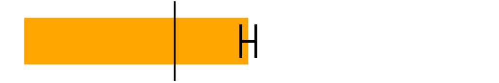

1.41

1.36–1.47

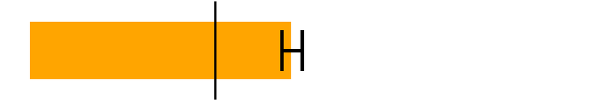

1.81

1.68–1.94

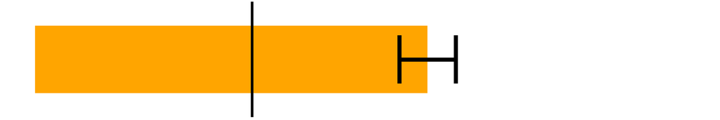

SIR (Boakye def. - 7)

1.46

1.40–1.51

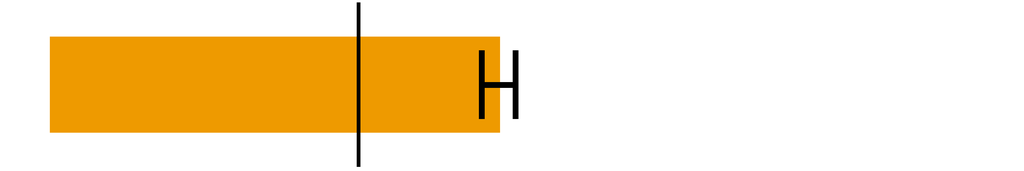

1.37

1.32–1.43

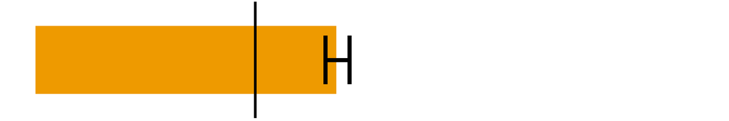

1.85

1.71–2.00

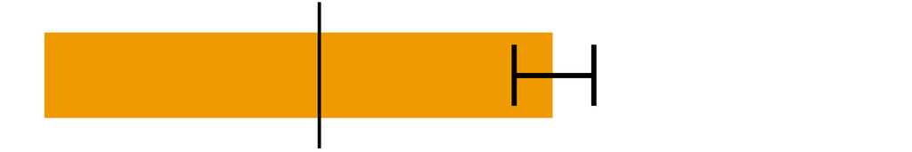

SIR (Barclay def. - 6)

1.67

1.59–1.75

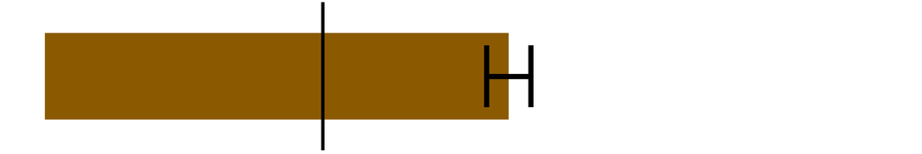

1.56

1.47–1.65

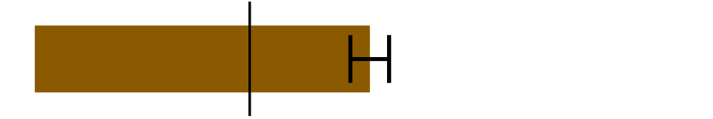

2.44

2.17–2.74

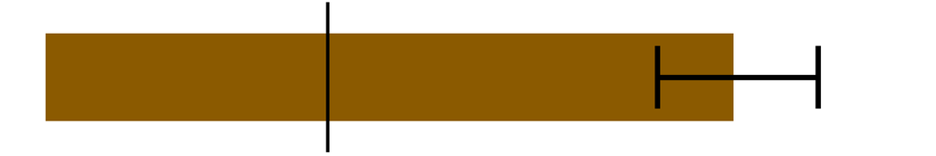

SIR other cancer